# Analisis evolutivo y correlativo del consumo de alcohol, tabaco y estado de salud

**Ex-fumador:**

**2009:**

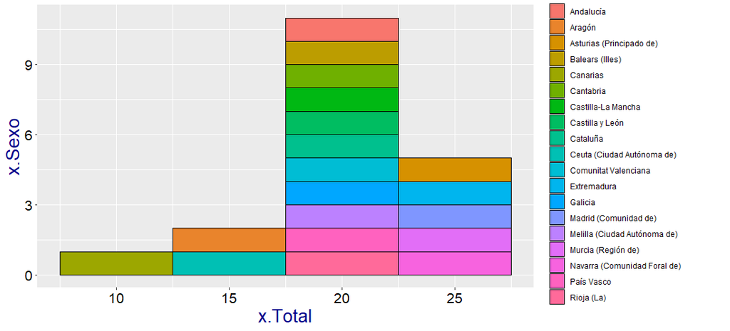

**2014:**

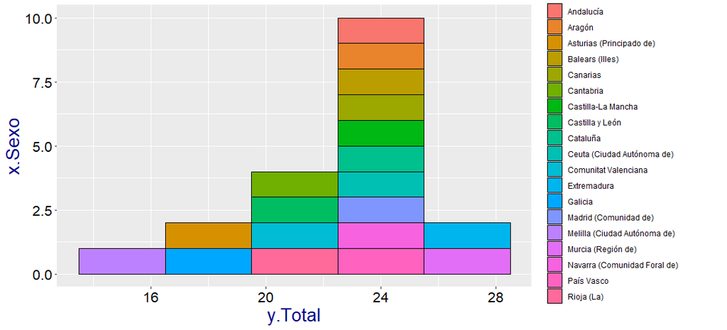

**2020:**

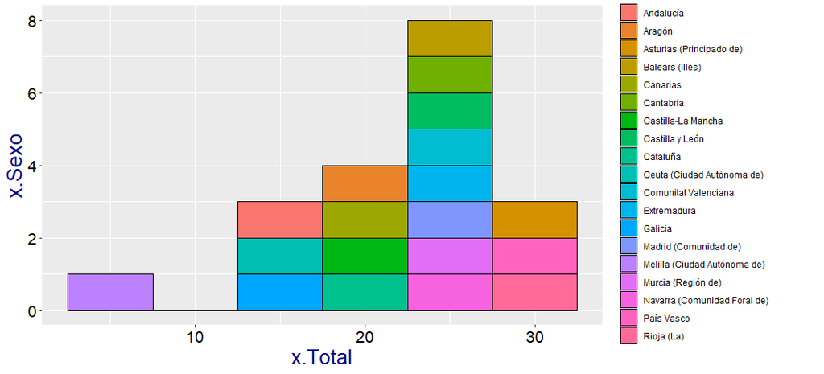

En la categoría de **ex-fumador** se observa lo resaltado en el anterior análisis, el número de ex-fumadores aumenta de manera general entre 2009 y 2014, sin embargo en 2020 no se observa un aumento similar, de hecho se puede observar un incremento en la dispersión de los datos. Desde el punto de vista de las comunidades autónomas cabe destacar el caso de Melilla que pasa de tener un porcentaje de ex-fumadores del 19 % en 2009 a un 14% en 2014 a un 6% en 2020. Las demás comunidades autónomas evolucionan de manera similiar entre ellas guardando una distribución parecida a la normal.

**No ha fumado nunca:**

**2009:**

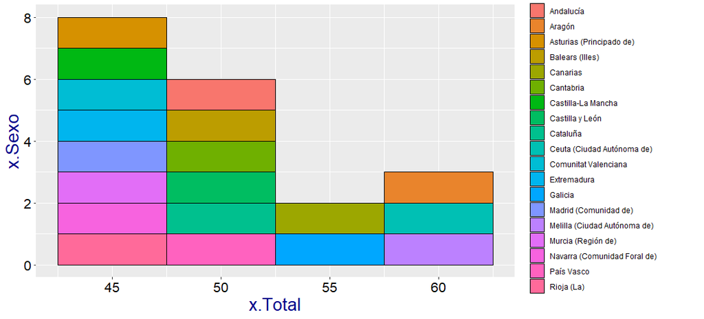

**2014:**

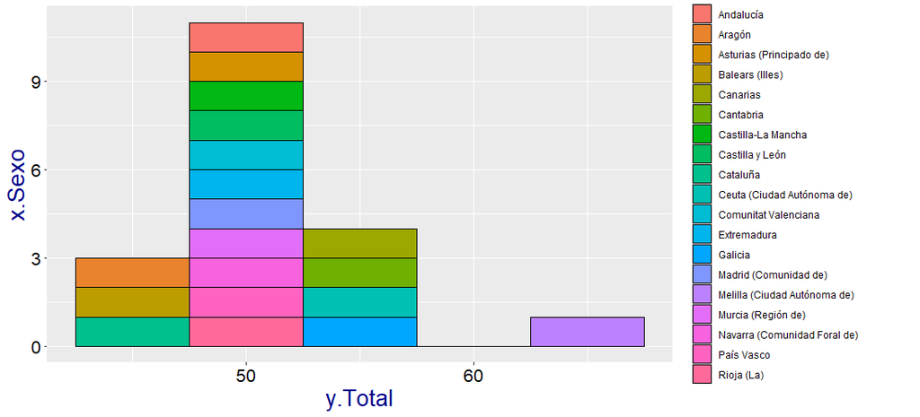

**2020:**

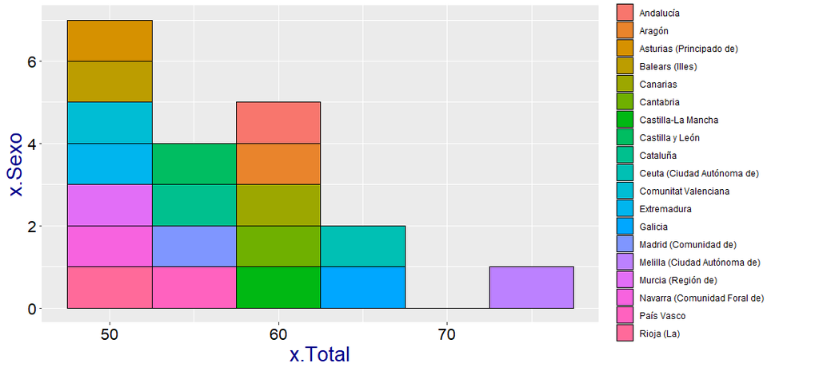

En la categoría de **no ha fumado nunca** se observa también un incremento homogéneo entre comunidades autónomas en la cantidad de personas que admiten no haber fumado nunca a través de los 3 años de las toma de datos. Melilla vuelve a ser un valor extremo dentro del dataset, alejándose de la media en 2014 y 2020.

Un aumento generalizado en el número de personas que no han fumado nunca presuntamente se correlaciona con un mejor estado de salud, posteriormente, en el análisis comparativo se verá si esto es cierto.

### Dataset: Estado de salud

Los distintos datasets escogidos referentes al estado de salud en los años 2009, 2014 y 2020 hacen el estudio sobre el estado de salud percibido en los últimos 12 meses, este se divide en 5 categorias: **Muy bueno, Bueno, Regular, Malo, Muy malo**.

En la carpeta de `input\data` estos datasets son **Estado_salud_2009.csv**, **Estado_salud_2014.csv,** **estado_salud_2020.csv**. Estos se corresponden a los número 6, 7 y 8 de Datos utilizados.

En los dos análisis que se harán sobre el dataset no se mostrarán los datos exactos correspondientes a la variable **Muy malo**, esto es debido a que es la que tiene proporción más baja y menos variabilidad, por lo que nos centraremos en las otras 4 variables categóricas. Si se desea profundizar más en el dataset se dejan las herramientas de trabajo a disposición del lector.

#### Análisis en función del sexo

Primeramente se analizará la distribución del total en cada variable categórica en función del sexo, esto se observará en un diagrama de caja y se observara la evolución de estas variables en los tres años de la toma de datos.

**2009:**

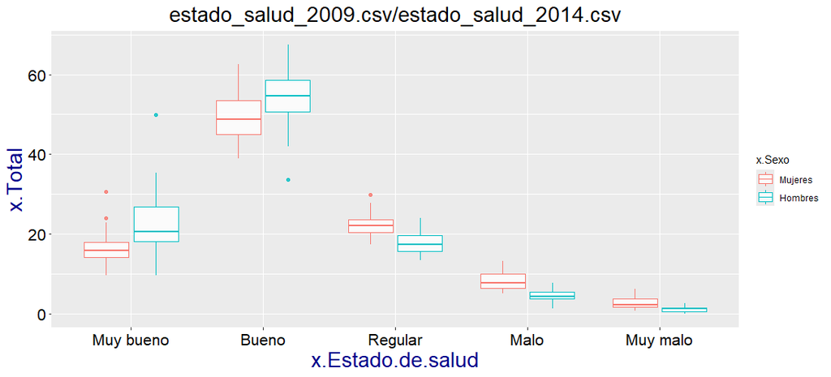

En el año 2009 la distribución de los datos nos muestra que una mayoría de las personas encuestadas percibe su estado de salud por encima de la categoría media, que sería **regular**. También se puede observar como los hombres tienden en general a percibir su estado de salud más positivamente en comparación con las mujeres, reflejándose este dato en las categorías de **Bueno y Muy bueno**, donde los hombres tienen una media de 53% y 22% respectivamente frente a un 49% y 17% en caso de mujeres.

Esta diferencia en las categorías superiores a favor de los hombres se contrapone con una diferencia a favor de las mujeres en las categorías de **Regular, Malo y Muy malo**.

Los valores estadísticos confirman estas observaciones:

Hombres/Muy bueno:

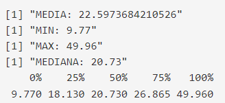

Mujeres/Muy bueno:

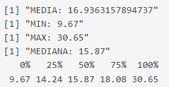

Hombres/Bueno:

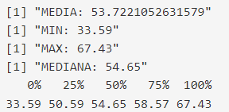

Mujeres/Bueno:

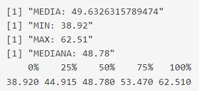

Hombres/Regular:

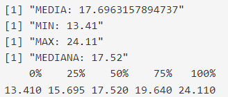

Mujeres/Regular:

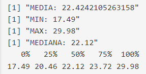

Hombres/Malo:

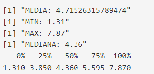

Mujeres/Malo:

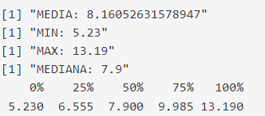

**2014:**

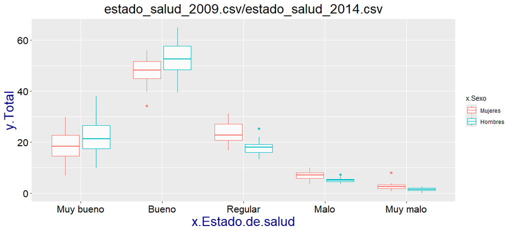

En cuanto a la dispersión, esta aumenta en la categoría de **Muy Bueno** para ambos sexos y en la categoría **Regular** para las mujeres.

Debido a la irrelevancia de estos cambios y favoreciendo la brevedad del documento se omiten las imágenes de los datos, si el lector desea revisarlos tiene a su disposición el Visor de Datos y los datasets de los que se habla.

**2020:**

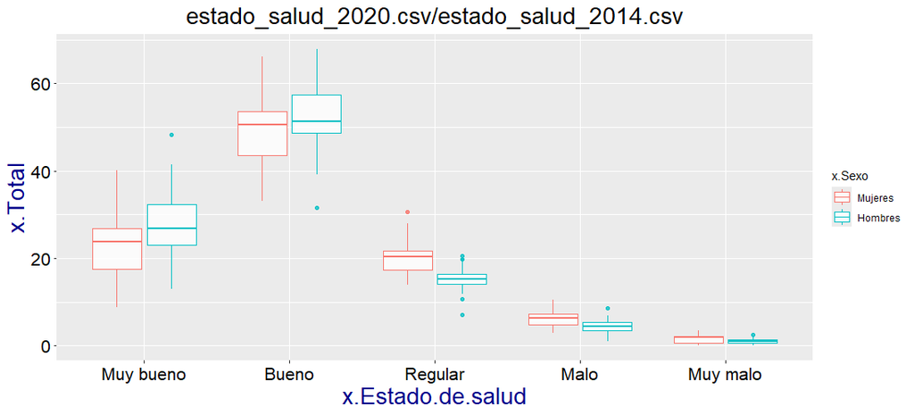

En 2020 sí que se puede observar un cambio significativo en la distribución de los datos. Primeramente se observa un aumento significativo en la categoría de **Muy Bueno** en ambos sexos, de un 18 % a un 22 % de media en caso de mujeres y de un 22 % a un 28 % en caso de hombres, este incremento afecta por igual a las demás categorías bajando todas de 1 a 2 puntos de media.

Estos cambios muestran una mejora en la salud percibida de la población que posteriormente se podrá relacionar con la evolución de otros determinantes de salud.

Los datos confirman estas observaciones:

Hombres/Muy bueno:

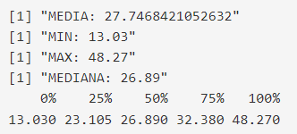

Mujeres/Muy bueno:

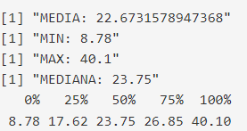

Hombres/Bueno:

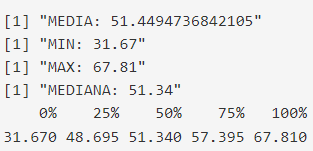

Mujeres/Bueno:

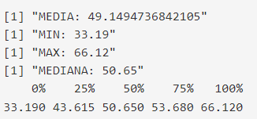

Hombres/Regular:

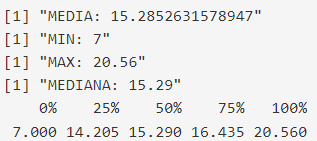

Mujeres/Regular:

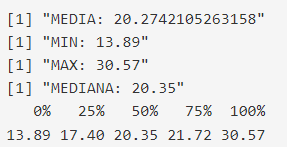

Hombres/Malo:

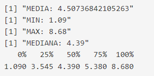

Mujeres/Malo:

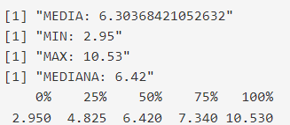

#### Analisis en función de las com. autonomas

También se analizará la evolución del estado de salud en las distintas comunidades autónomas, para ello se visualizará un histograma con los datos de cada categoría (**Muy bueno, Bueno, Regular, Malo**) en los distintos años de toma de datos, en estos histogramas se podrá ver a través del mapping las comunidades autónomas.

Los datos son filtrados en función de la variable “Ambos Sexos”, por lo que solo existe una instancia de cada dato para cada comunidad autónoma.

**Muy Bueno**

**2009:**

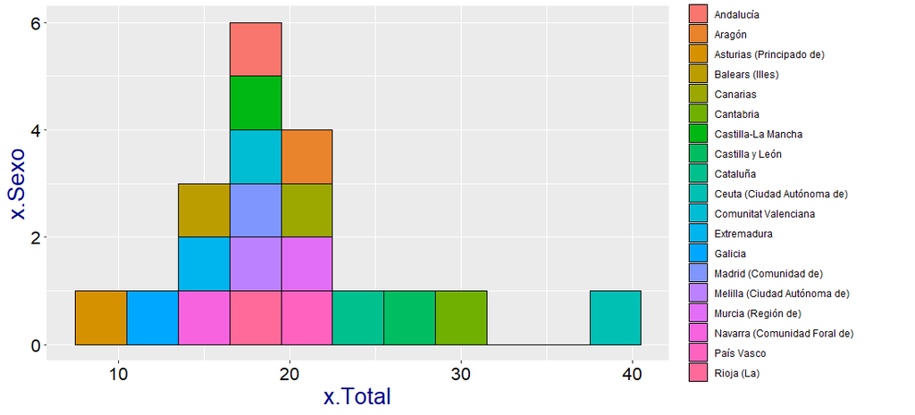

**2014:**

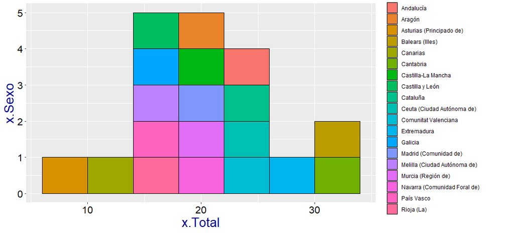

**2020:**

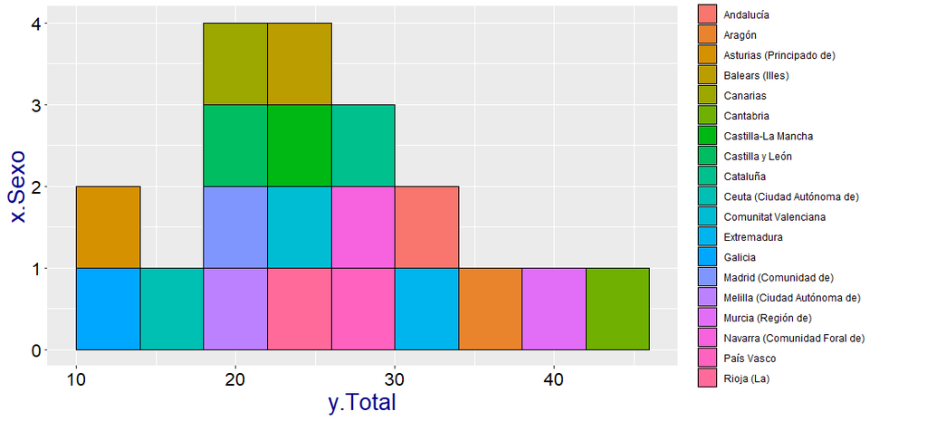

**Bueno:**

**2009:**

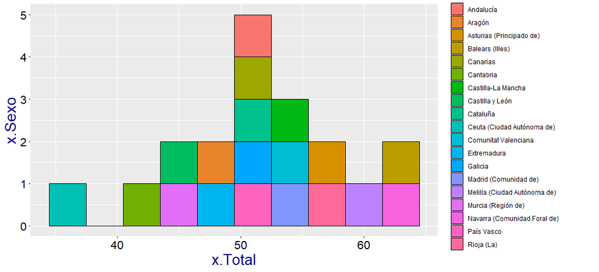

**2014:**

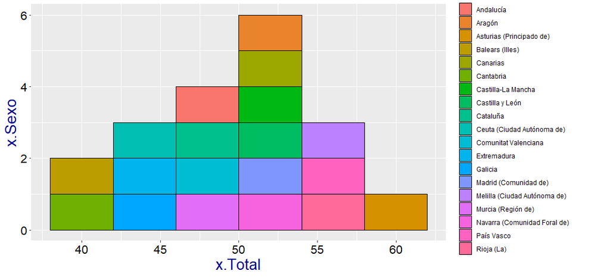

**2020:**

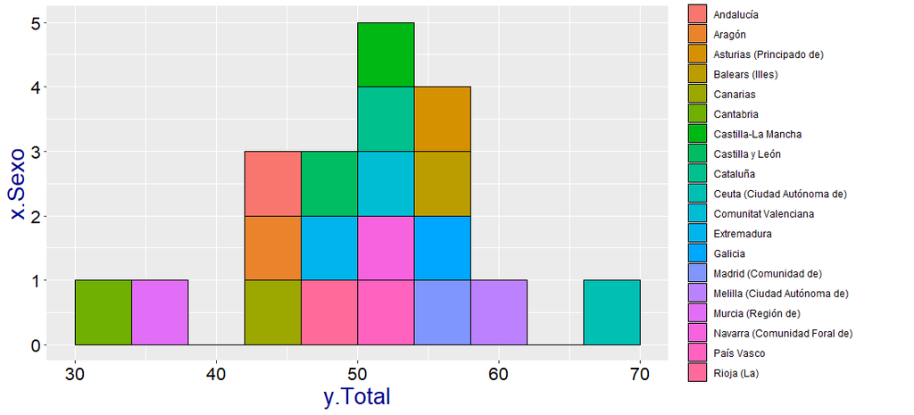

En la categoría de **Bueno** se puede observar como pese a la invariabilidad aparente de esta variable desde el 2009 al 2020 (se mantiene en un 50-51% de media), los datos individuales en cada comunidad autónoma sufren grandes cambios y la dispersión también se modifica, esta pasa de un 36-63 % en 2009 a un 40-60 % en 2014 a un 32-67% en 2020.

**Regular:**

**2009:**

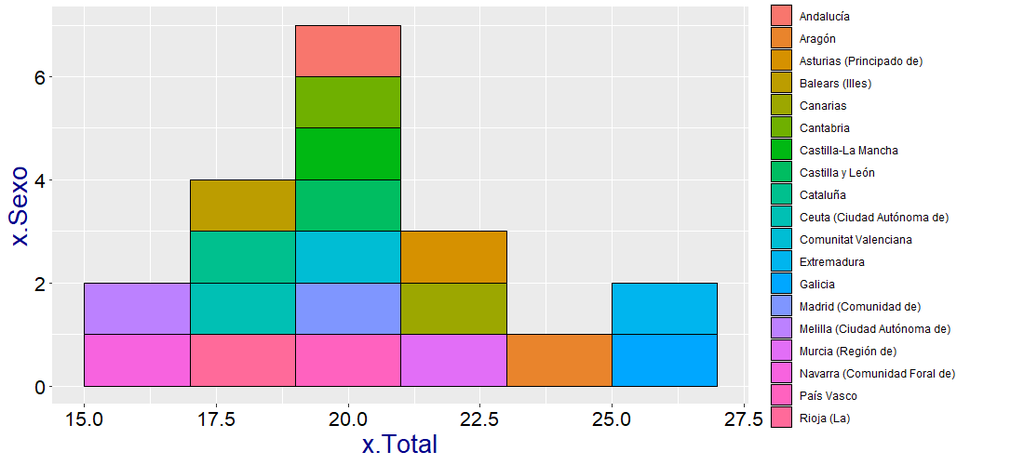

**2014:**

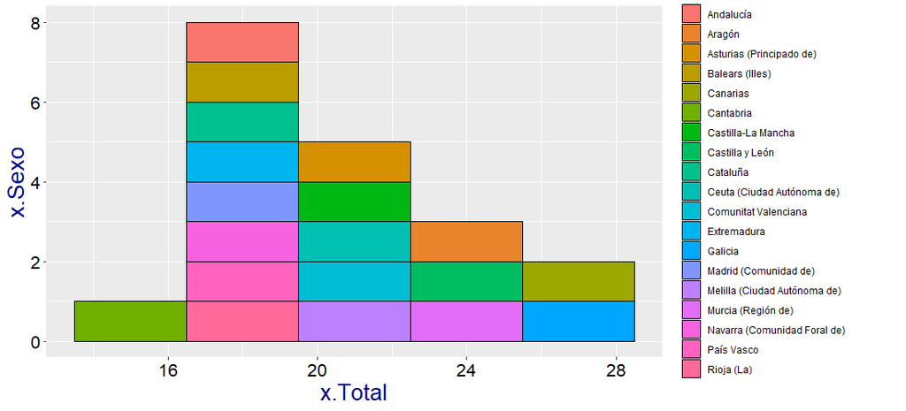

**2020:**

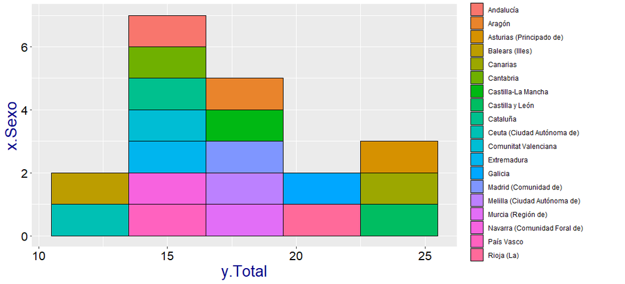

En la categoría de **Regular** se puede observar como frente a un pequeño cambio en la media durante los años 20%-20%-17% la dispersión no varía significativamente y tampoco hay grandes cambios individualmente en las comunidades autónomas. Esto se debe probablemente a que los mayores cambios en proporción se producen en las categorías de Muy bueno y Bueno, en las que, por su cercanía, se puede producir un transbase de gente, al contrario en las categorías bajas de **Regular, Malo y Muy Malo,** la variabilidad y los cambios son de menor escala, o en este caso, insignificantes para sacar alguna conclusión. Igualmente se deja a disposición del lector las gráficas y los datos para más introspección del tema.

**Malo:**

**2009:**

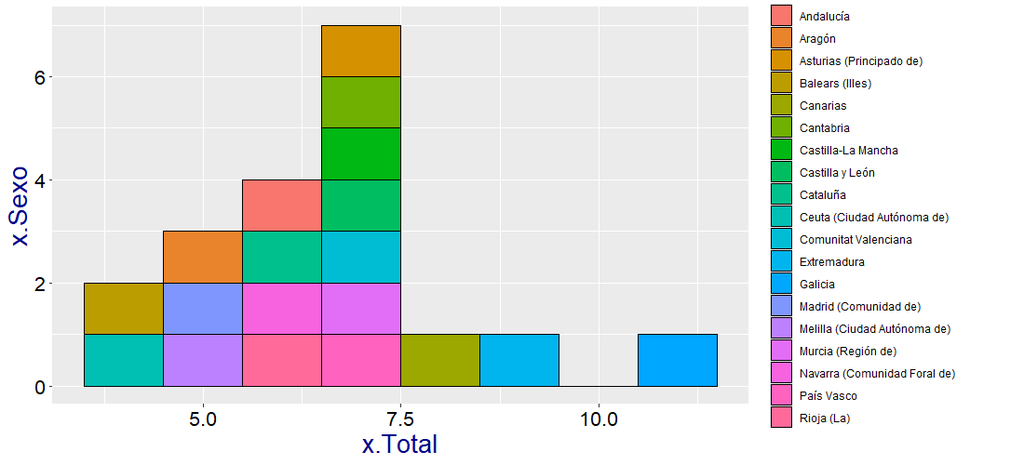

**2014:**

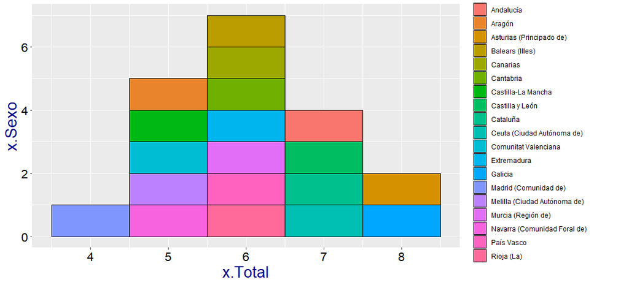

**2020:**

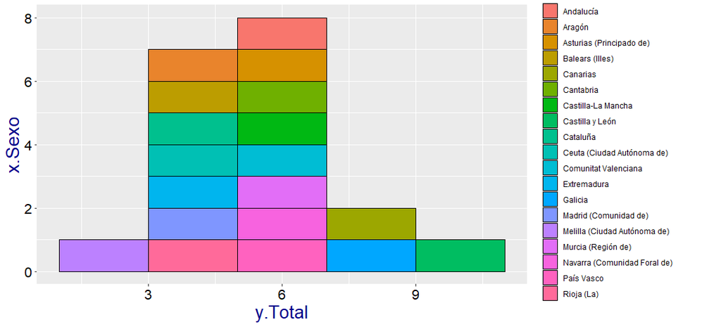

Denotar la aparente distribución normal de los datos, que pese a no haberlo comentado anteriormente, es común en todos los histogramas mostrados en este análisis.

## Análisis correlativo y Conclusiones

Habiendo analizado los datasets anteriormente presentados se procederá a establecer una correlación entre la evolución de los determinantes como el consumo de alcohol y el tabaco y el estado de salud. Este análisis correlativo se realizará primeramente en función del sexo y posteriormente en función de las comunidades autónomas.

#### Análisis en función del Sexo

Si quisieramos resumir las coclusiones extraidas del análisis evolutivo en función del sexo de los datasets presentados acabaríamos con la siguiente información:

**Consumo de Alcohol:** tal y como se explica en el Analisis en función del sexo del Dataset: Alcohol, el consumo de Alcohol varía en el país desde 2009 hasta 2020 reflejándose esta variación en el caso de los hombres como un descenso en la tasa del consumo de 2 puntos de media y en el caso de las mujeres como un ascenso en 5 puntos, acabando con una media de 72% y 55 % respectivamente. Si bien los cambios en caso del sexo masculino no son significativos no se puede decir lo mismo de las mujeres, cuyo aumento en la tasa del consumo es suficiente para marcar una tendencia.

Incluso cuando las modificaciones son pequeñas durante los años hay que denotar que la tasa del consumo de alcohol en el país es relativamente alta en comparación con otros paises de la UE (https://www.sanidad.gob.es/ca/alcoholJovenes/docs/alcoholEuropaEspanol.pdf) y se ha demostrado en infinidad de estudios que esta gran tasa de consumo no beneficia el estado de salud del país.

**Consumo de tabaco:** como se puede observar en el Analisis en función del sexo del Dataset: Consumo de tabaco, el consumo de tabaco disminuye de manera significativa desde el año 2009 hasta 2020, reduciendose la media del número de fumadores diarios de un 31 % a un 23 % en caso de hombres y de un 21 % a un 16 % en caso de mujeres. Estos decrementos combinados con el aumento de las personas que admiten nunca haber fumado desde un 31% a un 47 % en caso de hombres y de un 61% a un 65% en caso de mujeres.

Los cambios en estos datasets nos indican una tendencia positiva hacia la disminución en el consumo de tabaco en ambos sexos, siendo esta más acuciada en caso de los hombres. El consumo de tabaco tiene grandes efectos en la salud del país y la reducción de este tendría que tener efectos positivos en esta.

**Estado de salud:** como se puede observar en el Análisis en función del sexo del Dataset: Estado de salud, el estado de salud percibido aumenta hacia calificaciones más positivas desde el año 2009 hasta el 2020, sin embargo, se puede ver como los hombres perciben su estado de salud más positivo que las mujeres. La media en la categoría **Muy bueno** pasa de un 22% a un 27% en caso de hombres y de un 17% a un 22 % en caso de mujeres. Esta diferencia también se refleja en la categoría de **Bueno** donde la diferencia evoluciona de 4 puntos en 2019 a 2 puntos en 2020.

El estado de salud percibido en el país evoluciona positivamente pero este aumento no es demasiado significativo, pese a ello un incremento sigue siendo buenas noticias y se puede relacionar con los determinantes estudiados.

**Conclusiones del análisis:**

En el caso de las mujeres el estado de salud mejora en menor medida en contraposición con los hombres, sin embargo, estos valores que muestran una tendencia positiva también son esperanzadores. Un incremento de 5 puntos de media en la categoría **Muy bueno** y un descenso de 2 puntos en las categorías de **Regular** y **Malo** que se pueden correlacionar con el descenso de la cantidad de fumadores diarios de un 21% a un 16% y el aumento de personas que nunca han fumado de un 61% a un 65%. Por parte del consumo de alcohol nos encontramos con un paradigma distinto ya que, entre mujeres, el consumo de alcohol a aumentado con los años, esto puede haber tenido inplicaciones negativas en el estado de salud. Las correlaciones se siguen haciendo en base a los estudios comentados anteriormente.

Cabe destacar que pese a que las cifras de consumo de tabaco y consumo de alcohol por parte de las mujeres son más bajas, estas también perciben su estado de salud de manera más negativa que los hombres, que tienen cifras peores en los determinantes comentados. Esta discrepancia puede ser debida a la multifactorialidad del llamado “Estado de salud” y también a las diferencias sociopsicológicas que existen entre hombres y mujeres.

#### Análisis en función de las com. autónomas

Para hacer el análisis en este aspecto se analizarán los datos de todas las comunidades autónomas por separado y se extrairan conclusiones de cada una de ellas:

**Andalucía:** En Andalucía se observa un aumento general del estado de salud como reflejan los datos en la categoría de **Muy bueno** que aumenta de un 19 % a un 33 % de 2009 a 2020, viéndose un descenso en las demás categoréas a raíz de esto. Este incremento puede estar debido a la reducción en el consumo de Alcohol desde un 59% a un 53 % de cosumidores y también a la reducción de fumadores diarios de un 26% a un 20%, todo esto en el periodo 2009-2020. Esta comunidad autónoma nos da un ejemplo de como una reducción en el consumo de Alcohol y tabaco se puede correlacionar con un aumento en el estado de salud.

**Aragón:** En Aragón se observa un aumento similar al explicado en Andalucia, en los datos de Estado de Salud se observa un aumento en la cartegoría **Muy bueno** del 21% al 35% entre 2009 y 2020 con el sucesivo descenso en las demás categorías. Esto se pude justificar observando como el consumo de tabaco se reduce pasando de haber un 24% de fumadores diarios a un 17% de acuerdo a los datos, el consumo de alcohol se mantiene constante pero aún por debajo de la media del país con un 59% de consumidores. En está comunidad también se ve una mejora del estado de salud percibido pese a no haber reducido su consumo de alcohol.

**Asturias:** En Asturias no varía significativamente el estado de salud percibido, aumentando en 1 punto en la categoría **Muy Bueno** y 2 en la categoría **Regular**, descendiendo en las demás. Esto puede deberse a un aumento en el consumo de Alcohol desde 2009 a 2020, pasando de un 65% a un 73%. El consumo de tabaco se reduce, siguiendo la tendencia general del país, sin embargo, no parece tener un efecto positivo en el estado de salud, igual debido a que esta reducción sirve para paliar los efectos adversos de la subida del consumo de alcohol.

**Islas Baleares:** En las Islas Baleares sí que se observa un incremento significativo en las cifras de la categoría **Muy bueno** pasando de un 14 % en 2009 a un 26% en 2020 y una reducción proporcional en las demás categorías, destaca el dato de la categoría **Muy malo** que se reduce a un 0.25% en 2020. Esto está en sintonía con una reducción del 5 % en la cantidad de fumadores diarios y una reducción del 2% en el comsumo de alcohol. Cabe mencionar que pese a no ser la comunidad en la que se ven los mayores decrementos del consumo de alcohol y tabaco sí que se produce una mejora considerable en el estado de Salud, probablemente debido a otras causas ajenas a las estudiadas.

**Canarias:** En las Islas Canarias se observa un pequeño deterioro del estado de Salud, reduciendose en 5% la categoría **Bueno** y aumentando en 4 % la categoría **Regular** y un 1% la categoría **Malo.** Esto se produce pese a un decremento en el consumo de Alcohol del 5% y un descenso en el número de fumadores diarios del 7%, lo que indica que este detrimento en el estado de salud se debe a causas no estudiadas en este análisis.

**Cantabria:** En Cantabria se observa un aumento muy significativo en la categoría de **Muy bueno** referente al estado de salud, en específico aumenta del 28% al 44% entre 2009 y 2020, reduciendo considerablemente la proporción en las categorías inferiores. Esta mejora se puede justificar observando como el numero de fumadores diarios se reduce de un 27% a un 18% en el mismo periodo de tiempo. Pese a todo esto cabe destacar que esta comunidad sufre un incremento muy considerable en el consumo de alcohol, aumentando de un 56% a un 73%.

**Castilla y León:** En Castilla y León se observa un detrimento considerable en el Estado de Salud, en la categoría **Muy bueno** hay una reducción del 8% (26%-18%) entre 2009 y 2020 y hay un aumento de 2% en la categoría **Malo** y de un 1% en la categoría **Muy malo.** Esto puede deberse a un aumento en el consumo de alcohol de un 56% a un 71%. Pese a eso, el consumo de tabaco disminuye un 10% siguiendo la tendencia de las demás comunidades autónomas.

**Castilla la Mancha:** En Castilla la Mancha se observa una ligera aunque significativa mejora en el estado de salud, aumentando al categoría de **Muy bueno** de un 17% a un 24 % seguido de una reducción proporcional de las demás categorías. Esto coincide con lo esperado viendo como el número de fumadores diarios se reduce en un 8% y el consumo de alcohol se mantiene constante en el periodo de tiempo entre las tomas de datos (2009-2020).

**Cataluña:** En Cataluña se puede observar un incremento del 3% en la categoría Muy bueno en los datos del estado de salud, un aumento ligero pero acorde a la también pequeña reducción en el número de fumadores diarios, solo un 4%. El consumo de alcohol se mantiene constante en el 69-70% de consumidores.

**Comunidad Valenciana:** En la comunidad Valenciana se observa un incremento significativo en el Estado de Salud pasando de un 17% a un 25 % en la categoría **Muy bueno** con su reducción proporcional en las demás categorías. Esto puede deberse al descenso en el número de **fumadores diarios** en un 9 % y el aumento de **no fumadores** en un 5%. Los datos de consumo de alcohol muestran una subida del 2 % en el consumo, la cual no es significativa para afectar al estado de salud.

**Extremadura:** En Extremadura se observa un gran aumento en los datos de la categoría **Muy bueno,** específicamente del 15 %. Esta mejora significativa se produce pese a las ligeras reducciones en el consumo de alcohol y de tabaco, concretamente del 1 % en caso del consumo de alcohol y del 2 % en caso del número de **fumadores diarios**.

**Galicia:** En Galicia se observa un ligero aumento del 2% en la categoría **Muy bueno** y un gran incremento del 7% en la categoría **Bueno** que conlleva la bajada de las demás categorías, estos datos nos indican una mejora en el estado de salud, que pueden deberse a una reducción del 4 % en el número de **fumadores diarios**, pese a esto el consumo de alcohol se mantiene en este mismo periodo (61-62%).

**Madrid:** En Madrid se observa una mejora del 3 % en la categoría de **Muy bueno** y del 1% en la categoría de **Bueno** que se puede correlacionar con una reducción del 8% en el número de **fumadores diarios** mientras que el consumo de alcohol se mantiene constante.

**Murcia:** En Murcia se observa un incremento significativa del 16 % en la categoría de **Muy bueno**, pasando de un 22% a un 38 % desde 2009 hasta 2020, esto se produce con la reducción sucesiva en las demás categorías. Esta mejora significativa puede relacionarse con una reducción del 4 % en el número de fumadores diarios. El consumo de alcohol se mantiene constante (64%) lo que nos hace pensar que la mejora en el estado de salud puede deberse a otras causas.

**Navarra:** En Navarra se observa también un incremento significativo en la categoría de **Muy bueno**, concretamente pasando de 12 % en 2009 a 26 % en 2020. Esta mejora se puede relacionar con una reducción de 10 % en la cantidad de **fumadores diarios.** Destacar igualmente un aumento del 10 % en el consumo de alcohol en el mismo periodo de tiempo.

**País Vasco:** En País Vasco se observa se ve una mejora en el estado de salud, reflejandose en un aumento del 6 % en la cataegoría **Muy bueno** con la sucesiva reducción de las demás categorías. Esto puede deberse a una reducción del 11 % en el número de **fumadores diarios**. Destacar que pese a una mejora en el estado de Salud también hay un aumento del 11 % en el consumo de alcohol en el mismo periodo de tiempo.

**La Rioja:** En La Rioja se observa un aumento del 7 % en la categoría de **Muy Bueno**, del 18 % al 25%, lo que indica una mejora en el estado de salud que puede relacionarse con una reducción del 11 % en el número de fumadores diarios. También se observa un aumento del 4 % en el consumo de alcohol.

**Ceuta:** En Ceuta se observa un gran desplome en el estado de salud, especificamente una reducción del 26 % en la categoría de **Muy bueno,** pasando de un 40 % a u 16%, sin embargo, esta reducción se refleja en un aumento casi similar en la categoría de **Bueno**. Estas cifras pueden deberse al aumento en un 7 % del consumo de alcohol, sin embargo, el consumo de tabaco sigue la tendencia general y baja un 11 % desde 2009 a 2020.

**Melilla:** En Melilla las cifras se mantienen constantes durante este periodo de tiempo, con un 19% en la catgoría **Muy bueno,** y un 60%, 16%, 4% en las siguientes respectivamente. Esta invariabilidad se mantiene pese a una reducción del 13 % en el consumo de alcohol y una reducción del 3 % en el consumo de tabaco.

En cuanto al análisis de las comunidades autónomas podemos concluir que existe una correlación entre el estado de salud y el consumo de tabaco y alcohol, sin embargo, el estado de salud es una variable multifactorial que depende de muchas más cosas que estos determinantes estudiados, por lo tanto, dentro del estudio de cada comunidad autónoma se pueden encontrar excepciones o datos que no apoyen completamente este análisis. Pese a todo, el objetivo de este estudio y, en conclusión, de este trabajo no deja de ser el de manejar y tratar distintos datasets por lo que tomese los resultados de este trabajo “con un grano de sal”.